# IENG477 UYGULAMALı İSTATİSTİK PROJE

# 1 HAZIRLAYANLAR

- Ahmet Furkan YILDIZ 20255040
- Elif BÜYÜKKÖSE 19255049
- Aydan ARSLAN 19255005
- Ebru EFE 19255060
- Recep Mert ŞIKTAŞ 20255062
- Mustafa Çağrı AKTAŞ 21255605

Öğretim Üyesi  
Doç. Dr. Özcan Mutlu

Pamukkale Üniversitesi  
Mühendislik Fakültesi  
Endüstri Mühendisliği Bölümü  
Denizli

# 2 İÇERİK

### 2.0.1 Covid-19

Yeni Koronavirüs Hastalığı (COVID-19), ilk olarak Çin’in Vuhan Eyaleti’nde Aralık ayının sonlarında solunum yolu belirtileri (ateş, öksürük, nefes darlığı) gelişen bir grup hastada yapılan araştırmalar sonucunda 13 Ocak 2020’de tanımlanan bir virüstür.

### 2.0.2 KONU

Omicron ve Delta arasındaki vaka ve ölüm sayılarının araştırılıp, analiz edilmesi ve grafik çizilip rapor oluşturulması.

### 2.0.3 Neden Bu Konuyu Seçtik

Dünyayı etkisi altına alan ve halen devam eden Covid-19 hastalığı hayatımızı büyük oranda değiştirmiştir. Bizde hayatımızı bu kadar yakından etkileyen Covid-19 hastalığını yakından incelemek istedik.

### 2.0.5 Hangi Paketleri Kullanıldı

Projede verilerin düzenlenmesi, grafiklerin çizilmesi ve istatisiksel analizlerin yapılması için aşağıda belirtilen paketler kullanılmıştır.

```r
library(tidyverse)
```

### 2.0.6 Hipotez Testi

```
    Delta varyantı Omicron varyantına göre vaka sayılarına oranla daha fazla ölüm oranına sahiptir.
```

### 2.0.7 Grafikler

**YAPILAN GRAFİKLERDE YAPILAN KARŞILAŞTIRMALARr**

- Vaka Sayısı - Tarih
- Varyantlara göre Vaka sayısının - Tarih
- Vefat Sayısı - Tarih
- Varyantlara göre Vefat Sayısı - Tarih
- Ölüm Oranı - Tarih
- Test Sayısı - Tarih

```r
library(readxl)
istatistik <- read_excel("C:/Users/Furkan/Desktop/istatistik.xlsx")
View(istatistik)
```

```r
summary(istatistik)
```

```
##      Tarih                     Bugunku_Vaka_Sayisi Bugunku_Test_Sayisi
##  Min.   :2021-07-06 00:00:00   Min.   :   905      Min.   : 90301
##  1st Qu.:2021-09-24 12:00:00   1st Qu.: 15148      1st Qu.:251233
##  Median :2021-12-14 00:00:00   Median : 23562      Median :347232
##  Mean   :2021-12-14 00:00:00   Mean   : 29771      Mean   :310747
##  3rd Qu.:2022-03-04 12:00:00   3rd Qu.: 29799      3rd Qu.:361843
##  Max.   :2022-05-24 00:00:00   Max.   :111157      Max.   :468152
##
##  Bugunku_Vefat_Sayisi Bugunku_İyilesen_Sayisi Varyant_Turu
##  Min.   :  3.0        Min.   :  1019          Length:323
##  1st Qu.: 65.0        1st Qu.: 13820          Class :character
##  Median :177.0        Median : 24245          Mode  :character
##  Mean   :151.6        Mean   : 29824
##  3rd Qu.:216.5        3rd Qu.: 31368
##  Max.   :309.0        Max.   :104409
##
##     Omicron           Delta        Omicron_Olum      Delta_Olum
##  Min.   :   905   Min.   : 5160   Min.   :  3.00   Min.   : 35.0
##  1st Qu.:  5549   1st Qu.:19949   1st Qu.: 25.75   1st Qu.:154.0
##  Median : 20005   Median :23846   Median :139.50   Median :203.0
##  Mean   : 36633   Mean   :22516   Mean   :122.51   Mean   :182.4
##  3rd Qu.: 67649   3rd Qu.:27688   3rd Qu.:183.50   3rd Qu.:228.0
##  Max.   :111157   Max.   :33860   Max.   :309.00   Max.   :290.0
##  NA's   :157      NA's   :166     NA's   :157      NA's   :166
##  Varyant_Olum_Orani    Mevsim           Omicron_Oran      Delta_Oran
##  Min.   :0.1836     Length:323         Min.   :0.1836   Min.   :0.2581
##  1st Qu.:0.3846     Class :character   1st Qu.:0.2808   1st Qu.:0.6999
##  Median :0.6184     Mode  :character   Median :0.3986   Median :0.8081
##  Mean   :0.6297                        Mean   :0.4560   Mean   :0.8134
##  3rd Qu.:0.8442                        3rd Qu.:0.5599   3rd Qu.:0.9198
##  Max.   :1.4713                        Max.   :1.0825   Max.   :1.4713
##                                        NA's   :157      NA's   :166
##   Omicron_Test      Delta_Test
##  Min.   : 90301   Min.   :184462
##  1st Qu.:182274   1st Qu.:281184
##  Median :351751   Median :342145
##  Mean   :307620   Mean   :314054
##  3rd Qu.:412272   3rd Qu.:356004
##  Max.   :468152   Max.   :365412
##  NA's   :157      NA's   :166
```

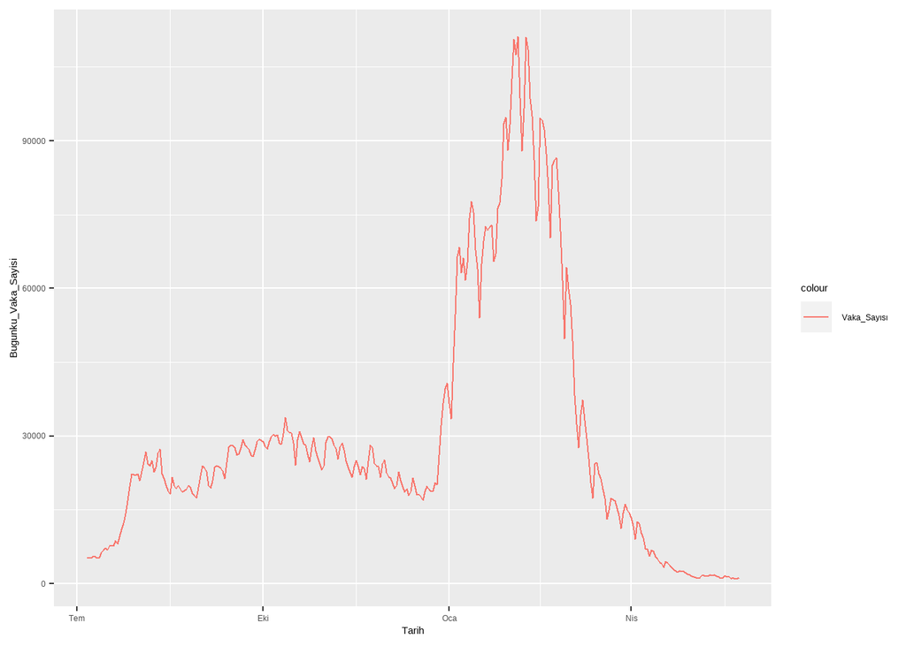

```r
ggplot(data = istatistik ,aes(x=Tarih, y= Bugunku_Vaka_Sayisi))+
   geom_line(aes( color="Vaka_Sayısı"))
```

```r
(echo = TRUE)
```

```
## [1] TRUE
```

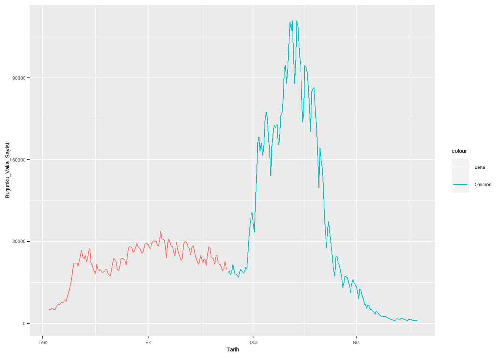

```r
library(tidyverse)
ggplot(data = istatistik ,aes(x=Tarih, y= Bugunku_Vaka_Sayisi))+
  geom_line(aes(y=Omicron, color="Omicron"))+
  geom_line(aes(y=Delta, color="Delta"))
```

```r
(echo=TRUE)
```

```
## [1] TRUE
```

Bu grafikte ise Delta ve Omicronun tarihlere göre vaka sayıları gösterilmektedir. 10.12.2021 tarihinde Omicron varyantı çıkmasıyla birlikte Omicronun Delta varyantına göre vaka sayılarında ciddi bir artış gözlemlenmiştir. Bu grafiği (Çizgi grafiği) seçmemizin nedeni tarihlere göre değişimleri daha net görebilmektir.

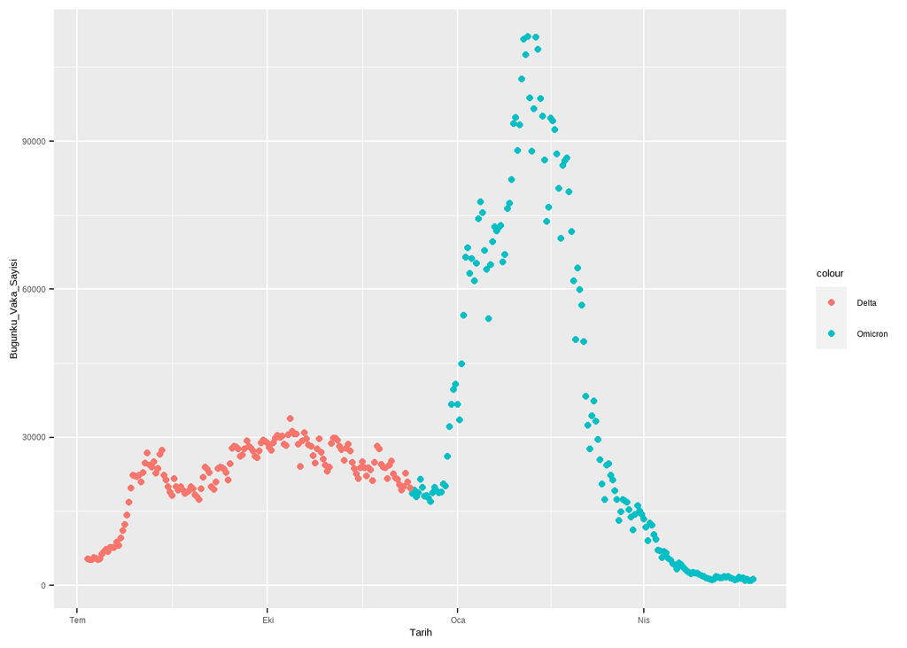

```r
ggplot(data = istatistik , aes(x=Tarih, y= Bugunku_Vaka_Sayisi ))+
  geom_point(aes(y=Omicron, color="Omicron"))+
  geom_point(aes(y=Delta, color="Delta"))
```

Günlük vaka sayısının tarihlere göre verilerinin nokta grafiği ile gösterimi.

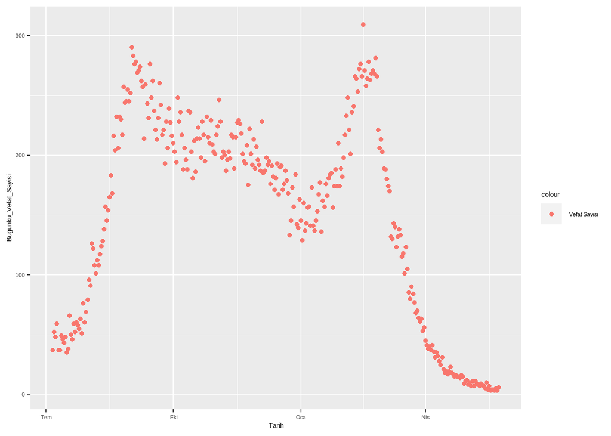

```r
ggplot(data = istatistik , aes(x=Tarih, y= Bugunku_Vefat_Sayisi ))+
  geom_point(aes(color="Vefat Sayısı"))
```

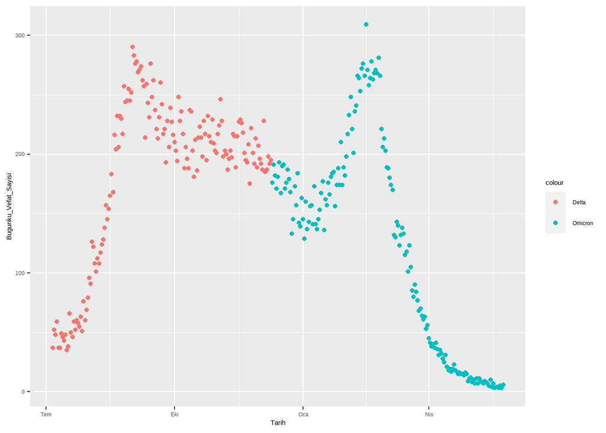

```r
ggplot(data = istatistik , aes(x=Tarih, y= Bugunku_Vefat_Sayisi ))+
   geom_point(aes(y=Omicron_Olum, color="Omicron"))+
  geom_point(aes(y=Delta_Olum, color="Delta"))
```

Delta varyantı tanısı konulduktan sonra Eylül ayına kadar vakalar artış göstermiştir. Eylül ayı ve Kasım-Aralık aylarında düşüşe geçmiştir. Omicron varyantı tanısı da aralık ayında konulmasıyla beraber vakalar tekrar artış göstermiştir. Omicron varyantında Şubat ayında pik noktası görüldükten sonra nisan ayına doğru ciddi bir düşüş gözlemlenmiştir.

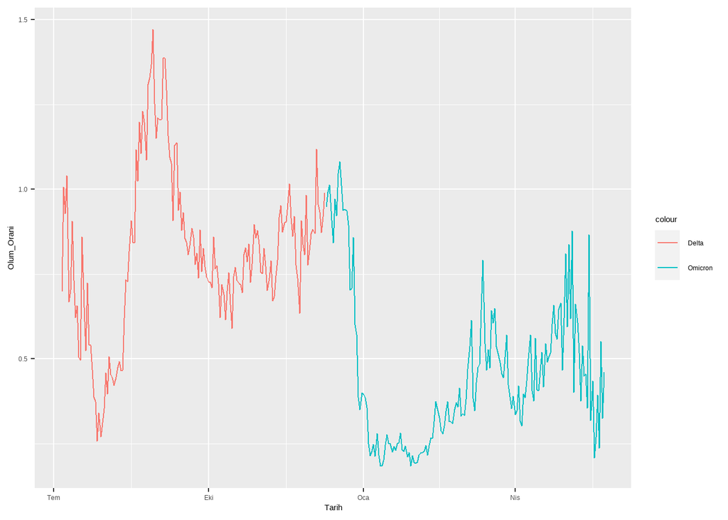

```r
library(tidyverse)
ggplot(data = istatistik ,aes(x=Tarih, y= Olum_Orani))+
  geom_line(aes(y=Omicron_Oran, color="Omicron"))+
  geom_line(aes(y=Delta_Oran, color="Delta"))
```

```r
(echo=FALSE)
```

```
## [1] FALSE
```

Yukarıdaki grafikte Delta ve Omicron varyantlarının vefat sayıları eşit gibi gözükmesine rağmen bu grafikte ölüm oranının Delta varyantında net bir şekilde Omicron varyantına göre daha fazla olduğu görülmektedir. Delta varyantında ölüm oranı, yaz aylarında düşüşe geçmiştir.

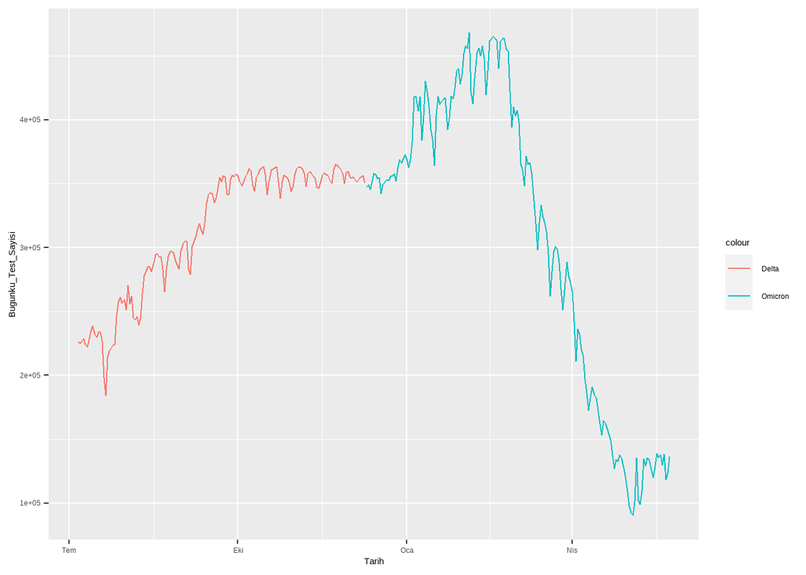

```r
library(tidyverse)
ggplot(data = istatistik ,aes(x=Tarih, y= Bugunku_Test_Sayisi))+
  geom_line(aes(y=Omicron_Test, color="Omicron"))+
  geom_line(aes(y=Delta_Test, color="Delta"))
```

```r
library(readxl)
istatistik1 <- read_excel("C:/Users/Furkan/Desktop/istatistik1.xlsx",
    col_types = c("date", "text", "numeric",
        "numeric", "numeric", "numeric",
        "numeric", "numeric", "numeric",
        "numeric", "numeric", "numeric",
        "numeric", "numeric", "numeric",
        "numeric", "numeric", "numeric",
        "numeric", "numeric"))
View(istatistik1)
```

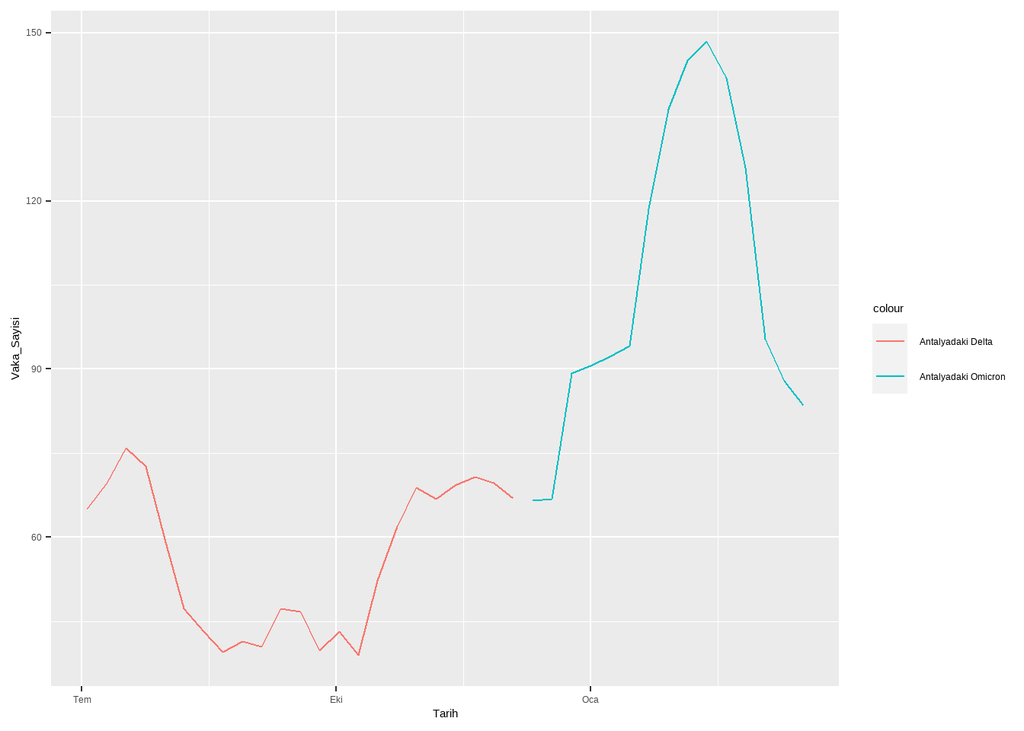

```r
library(tidyverse)
ggplot(data = istatistik1 ,aes(x=Tarih, y=Vaka_Sayisi))+
  geom_line(aes(y=Antalya_Omicron, color="Antalyadaki Omicron"))+
  geom_line(aes(y=Antalya_Delta, color="Antalyadaki Delta"))
```

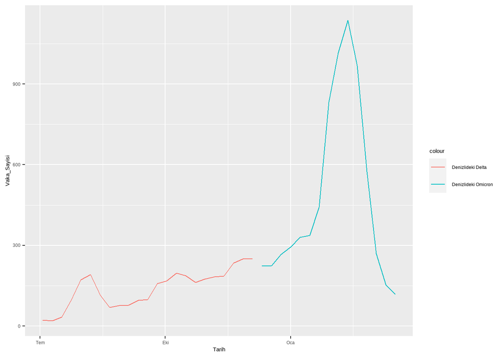

```r
library(tidyverse)
ggplot(data = istatistik1 ,aes(x=Tarih, y=Vaka_Sayisi))+
  geom_line(aes(y=Denizli_Omicron, color="Denizlideki Omicron"))+
  geom_line(aes(y=Denizli_Delta, color="Denizlideki Delta"))
```

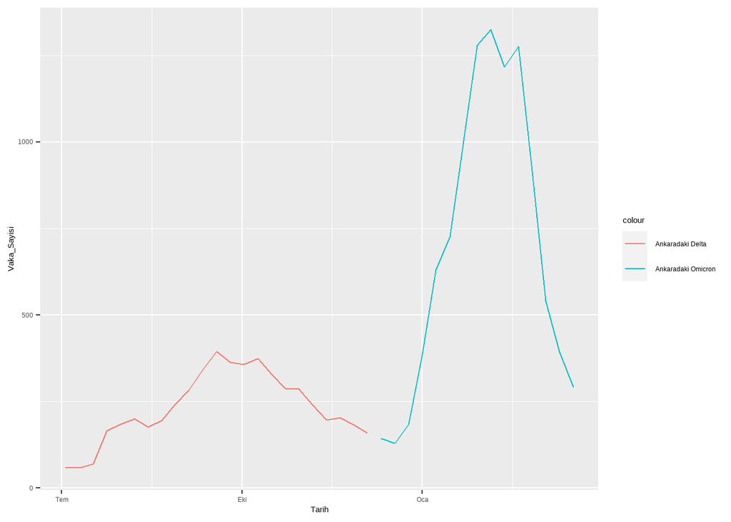

```r
library(tidyverse)
ggplot(data = istatistik1 ,aes(x=Tarih, y=Vaka_Sayisi))+
  geom_line(aes(y=Ankara_Omicron, color="Ankaradaki Omicron "))+
  geom_line(aes(y=Ankara_Delta, color="Ankaradaki Delta "))
```

# 3 HİPOTEZ TESTLERİ

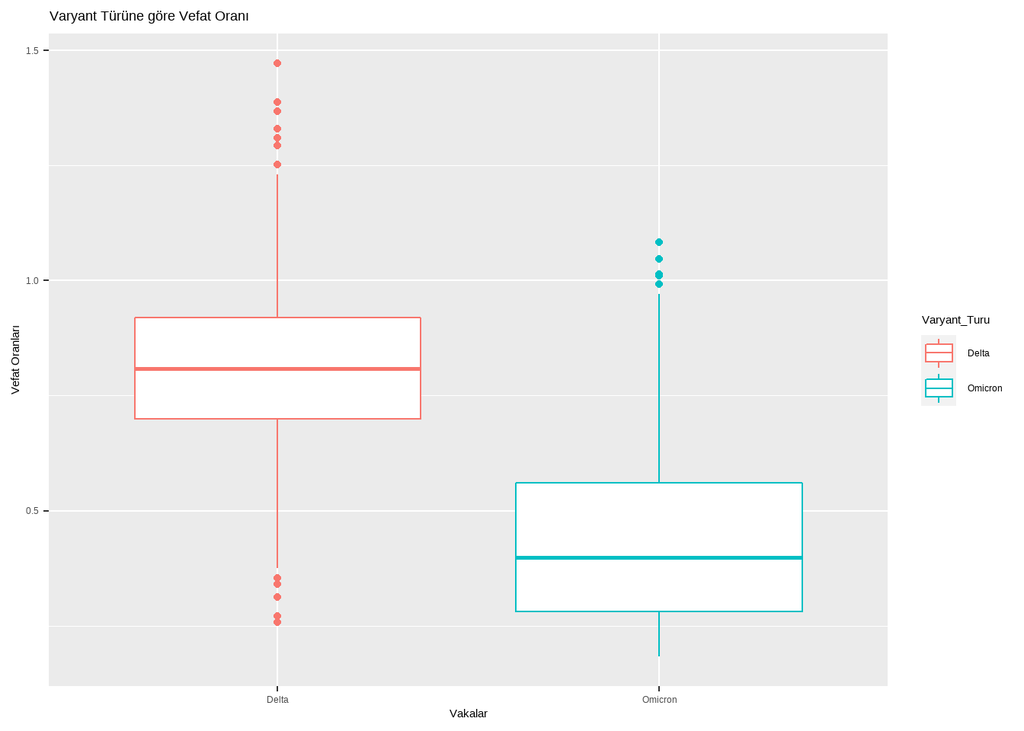

```r
istatistik%>%group_by(Varyant_Turu)%>%ggplot()+
  aes(x=Varyant_Turu, y=Varyant_Olum_Orani)+
  geom_boxplot(aes(colour=Varyant_Turu))+
  labs(
    x="Vakalar",
    y="Vefat Oranları",
    title = "Varyant Türüne göre Vefat Oranı")
```

Yukarıdaki grafikte kutular birbirine yakın olmadığı için ölüm oranları arasındaki değişim olduğu açıkça görülmektedir.

Delta varyantının öldürme oranının Omicron Varyantına göre farkı açıkça görülmektedir.

Delta ve Omicron Varyanıtının Öldürme Oranlarını karşılaştırmak için Varyant türlerine göre ölüm oranlarının ortalamasını hesaplayalım. Bunun için önce group_by() fonksiyonu ile Varyant türüne göre gruplandırıp daha sonra summarise() fonksiyonu Ölüm oranları bazında ortalamaları hesaplayabiliriz.

```r
istatistik%>%group_by(Varyant_Turu)%>%
  summarise(mean=mean(Varyant_Olum_Orani))%>%
  knitr::kable(
    col.names=c("Varyant Turu", "ölüm oranlarının Ortalaması"),
    digits = 3
    )%>%
  kable_styling(full_width = FALSE)
```

| Varyant Turu | ölüm oranlarının Ortalaması |
| --- | --- |
| Delta | 0.813 |
| Omicron | 0.456 |

$$H_0: \mu_{Deltanın Oldurme Oranı}=\mu_{Omicron Oldurme Oranı}\\
H_1: \mu_{Deltanın Oldurme Oranı} \ge \mu_{Omicron Oldurme Oranı}$$

## 3.1 T Testi

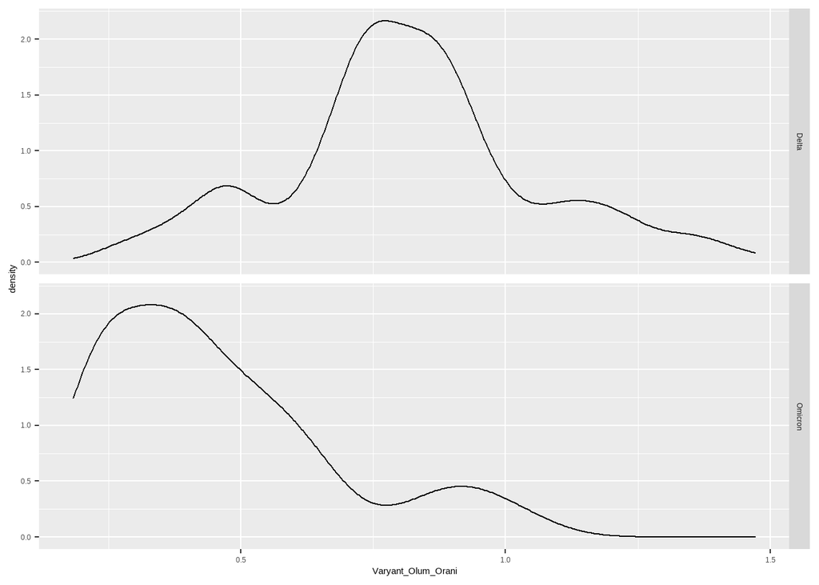

```r
ggplot(istatistik, aes(x =Varyant_Olum_Orani )) +
  geom_density(colour = "black") +
  facet_grid(Varyant_Turu ~ .)
```

Bu grafiklerden verilerin kısmen normal dağılıma sahip olduğu görülmektedir.

Bu grafiğimizde Omicron ölüm oranının yüksek çıktığı yerlerde vaka sayısının azalıp ölüm oranının arttığı görülmektedir.Daha sonrasında ise git gide ölüm oranının azaldığını görmekteyz.

Aynı şekilde Delta içinde Ölüm oranının başlarda ve sonlarda düşük çıkmasının nedeni pozitif vaka sayısının fazla olup ölüm Vefat sayısının azalmış olmasıdır.Ölüm oranının arttığı yerlerde ise vaka sayısının düşük olup vefat sayılarının fazla olduğu şeklinde yorumlayabiliriz.

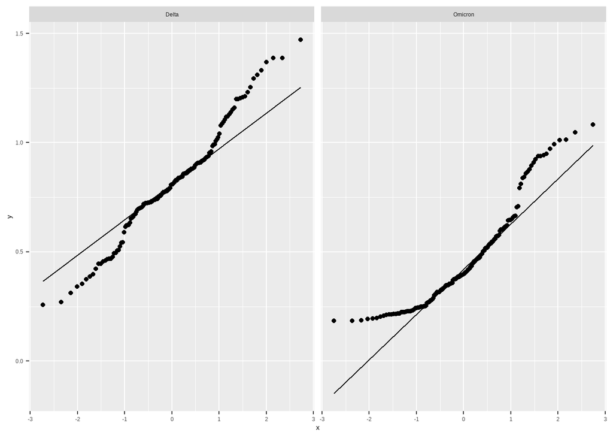

```r
ggplot(data=istatistik, aes(sample=Varyant_Olum_Orani))+
 stat_qq(distribution = qnorm)+
  stat_qq_line(distribution = qnorm)+
  facet_grid(.~Varyant_Turu)
```

İkinci grafikte noktaların bir kısmı çizgi üzerinde bulunmadığı için verilerin normal dağılıma sahip olmadığını Birinci grafikte ise kısmen normal dağılıma sahip olduğunu söyleyebiliriz.

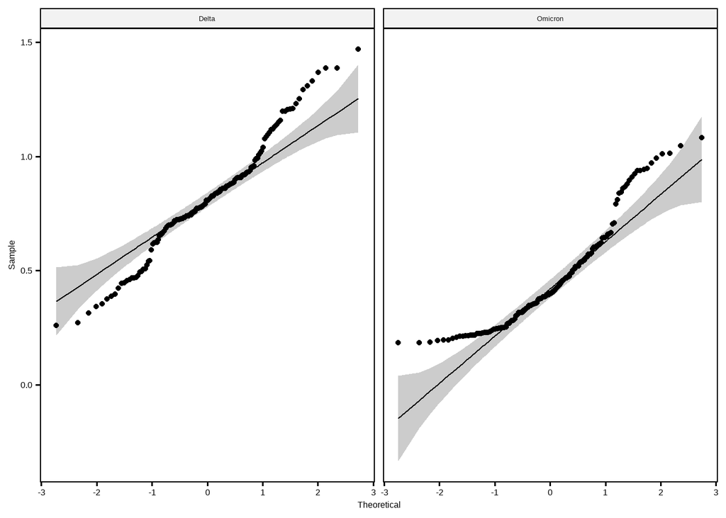

```r
ggqqplot(istatistik, "Varyant_Olum_Orani", facet.by="Varyant_Turu",)
```

Delta Varyantına ait verilerin bir kısmının güven aralığının dışında olduğundan kısmen normal dağılıma sahip olduğu görülmektedir.

### 3.1.1 Shapiro-Wilk testi

$$\begin{align}
&H_0: \text{Veriler normal dağılıma sahiptir}\\
&H_1: \text{Veriler normal dağılıma sahip değildir}
\end{align}$$

```r
istatistik %>%
  group_by(Varyant_Turu) %>%
  normality(Varyant_Olum_Orani)%>%flextable()
```

| variable | Varyant_Turu | statistic | p_value | sample |
| --- | --- | --- | --- | --- |
| Varyant_Olum_Orani | Delta | 0.9792593 | 0.018265964390931 | 157 |
| Varyant_Olum_Orani | Omicron | 0.8970534 | 0.000000002347739 | 166 |

```r
test=t.test(data=istatistik, Varyant_Olum_Orani~Varyant_Turu, alternative="two.sided", var.equal=TRUE)
test
```

```
##
##  Two Sample t-test
##
## data:  Varyant_Olum_Orani by Varyant_Turu
## t = 13.989, df = 321, p-value < 2.2e-16
## alternative hypothesis: true difference in means between group Delta and group Omicron is not equal to 0
## 95 percent confidence interval:
##  0.3070939 0.4076088
## sample estimates:
##   mean in group Delta mean in group Omicron
##             0.8133922             0.4560408
```

Yukarıdaki tabloda pdeğeri<0.05 olduğundan H0 hipotezi reddedilir. Delta varyantı ile Ölüm Oranı arasındaki ilişkinin normal dağılıma sahip olmadığı (0.018265964390931<0.05) ve Omicron Varyantı ile ölüm oranı arasındaki ilişki normal dağılıma sahir değildir. hipotez reddedilir. (0.000000002347739<0.05)

Grafikler ve Shapiro-Wilk testi sonuçlarından Delta ve Omicron varyantlarına ait verilerin normal dağılıma sahip olmadığını söyleyebiliriz. Ancak delta varyantının normal dağılıma daha yakın olduğu görğlmektedir.0.018265964390931<0.05)

Yukarıdaki sonuçlarda p-value<0.05 olduğundan H0 hipotezi reddedilir. Veriler normal dağılıma sahip değildir.

```r
istatistik%>%group_by(Varyant_Turu)%>%
  summarise(mean=mean(Varyant_Olum_Orani))%>%
  knitr::kable(
    col.names=c("İyilesen Sayisi", "Vefat Sayisi"),
    digits = 3
    )%>%
  kable_styling(full_width = FALSE)
```

[output not shown]

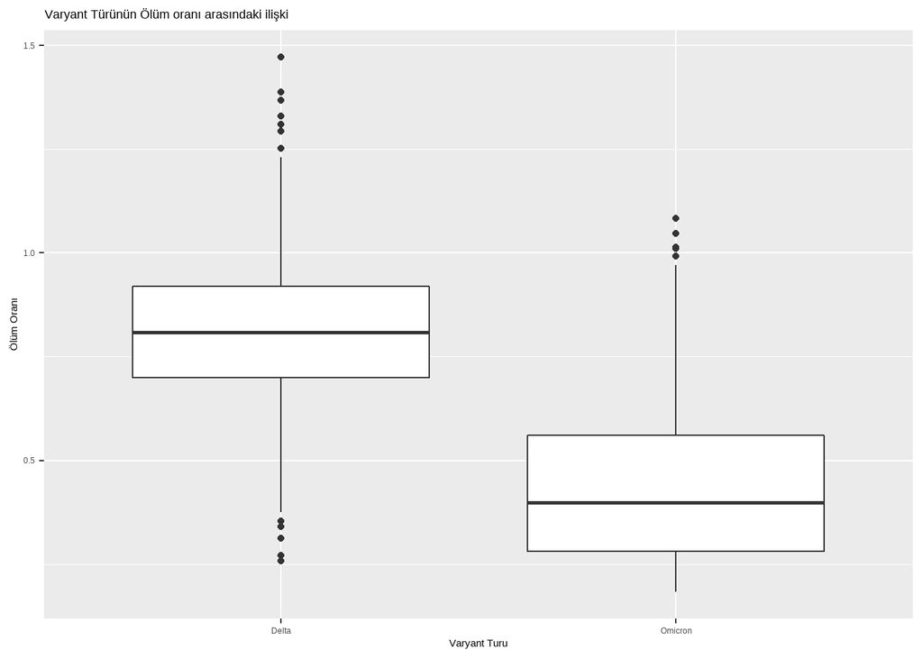

```r
ggplot(istatistik)+
  aes(x=Varyant_Turu, y=Varyant_Olum_Orani)+
  geom_boxplot()+
  labs(
    x="Varyant Turu",
    y="Ölüm Oranı",
    title = "Varyant Türünün Ölüm oranı arasındaki ilişki")
```

Delta Ölüm oranının Omicron ölüm oranına göre daha fazla olduğu iddiasını doğru olup olmadığını verilerin normal dağılıma sahip olduğunu varsayarak t testi ile belirleyelim. Bunun için hipotezleri aşağıdaki gibi oluşturabiliriz.

$$H_0: \mu_{Omicron Ölüm Oranı}=\mu_{Delta Ölüm Oranı}\\
H_1: \mu_{Omicron Ölüm Oranı}<\mu_{Delta Ölüm Oranı}$$

```r
test2=t.test(data=istatistik, Varyant_Olum_Orani~Varyant_Turu , var.equal=TRUE)
test2
```

```
##
##  Two Sample t-test
##
## data:  Varyant_Olum_Orani by Varyant_Turu
## t = 13.989, df = 321, p-value < 2.2e-16
## alternative hypothesis: true difference in means between group Delta and group Omicron is not equal to 0
## 95 percent confidence interval:
##  0.3070939 0.4076088
## sample estimates:
##   mean in group Delta mean in group Omicron
##             0.8133922             0.4560408
```

## 3.2 Kİ-KARE TESTİ

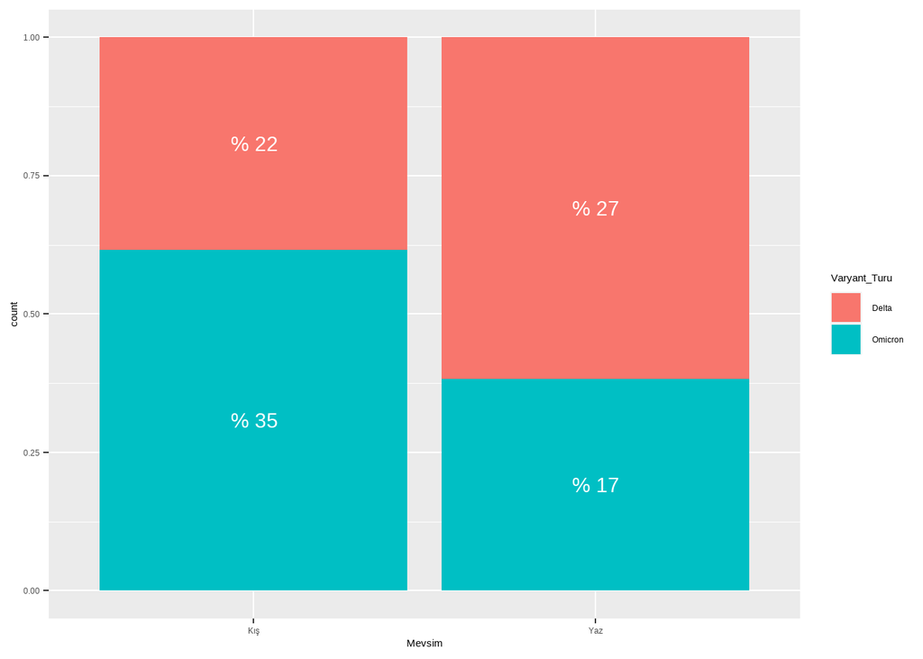

```r
ggplot(istatistik,aes(x=Mevsim, fill=Varyant_Turu))+
  geom_bar(position = "fill")+
  stat_count(geom = "text",
             aes(label = paste( "%", round((..count..)/sum(..count..)*100))),
             position=position_fill(vjust=0.5), colour="white",size=8)
```

```r
tablo <- as.matrix(table(istatistik$Mevsim , istatistik$Varyant_Turu))
tablo
```

```
##
##       Delta Omicron
##   Kış    70     112
##   Yaz    87      54
```

```r
chisq.test(tablo,correct = TRUE)
```

```
##
##  Pearson's Chi-squared test with Yates' continuity correction
##
## data:  tablo
## X-squared = 16.261, df = 1, p-value = 5.52e-05
```

# 4 Sonuç

Uygulamalı İstatistik dersi kapsamında yapılan projenin, sağlık bakanlığının yayımladığı veriler doğrultusunda Covid-19 virüsü üzerine araştırmalar yapılmış ve bu araştırma sonucunda istatistiksel analiz ve testlerle Covid-19’un insanlara bulaşıcılığı, vefat, omicron ve delta varyantları arasındaki ilişkiler incelenmiştir. Projenin odak konusu, Omicron varyantı ve Delta varyantı arasındaki tarihsel vaka sayıları ve ölüm sayılarının analiz edilip rapor oluşturulmasıdır.

Genel Covid-19 vaka sayıları incelendikten sonra 10.12.2021 tarihinde Omicron varyantının çıkmasıyla, Delta ve Omicron arasındaki ilişkinin incelenmesi için ilk olarak tarihlere göre varyantlıların vaka sayıları incelenmiştir. İlk iki grafikte kullanılan (çizgi grafiği) tarihlere göre veriler çekildiği için verilerin yoğunluğunun daha net incelenebilmesi için kullanılmıştır. Bu gözlemle vaka sayılarının ocak ayından sonra yükselişe geçtiği gözlemlenmiştir. Projenin ikinci kısmında Hipotez Testlerine yer verilmiştir. Bu kısımda “T Testi”, “Shapiro – Wilk Testi”, “Ki – Kare Testi” hazırlanarak grafiklerle yorumlanmıştır.

Hipotez testlerinin ilk yorumlanışı, varyant türüne göre vefat oranını delta ve omicron olarak iki kategoride incelenmiştir. Delta varyantının öldürme oranının omicron varyantına göre farkı kesin olarak gözlenmiştir.

Olarak verildiğinde, Delta varyantının öldürme oranı Omicron varyantının öldürme oranından daha fazladır hipotezi vardır.